# Monetary Donations, Government Expenditure, and Giving Prices (Tentative)

2020/12/25

# Crowding-out Effect of Governement Expenditure

地方政府が住民の利益になるような政策を実施することをその地域での公共財投資とみなして、 地方政府の支出の増加による金銭的寄付のクラウディングアウトの程度を分析する。

## データと分析手法

NaSTaBより、我々は時点$t$において地域$j$に住む個人$i$の寄付行動を観察することができる。 そこで、個人の寄付額の対数値（`log_total_g`）を$\log D_{ijt}$とする。 年間の労働所得の対数値（`log_pinc_all`）を$\log I_{ijt}$とする。 労働所得に基づいた所得税の限界税率（`mtr`）を計算できるので、 2014年以前は1から限界税率を差し引いた値を寄付価格とし、2014年以降は0.85が共通の寄付価格となる。 寄付価格の対数値は$\log P_{ijt}$とする。 さらに、このデータセットから、「いまの納税に対して政府の公共政策の規模は十分か」という質問に対する 5段階評価（`welfare_level`）を用いる。 サンプルサイズの確保のために、これを三段階（`welfare_level_3scale`）に集約する。 この変数はロバスト分析に使用する。

また、時点$t$における地域$j$を統治する政府の支出のデータを持っている（**Sourceはどこ？**）。 地方政府の支出の対数値を$\log G_{jt}$とする。 政府支出は社会福祉分野（`log_PPP_pubbdg`）と保健分野（`log_PPP_healthbdg`）に分けられる。 この二つの分野の違いは以下の通りである。

- 社会福祉分野：基礎生活保障、脆弱階層支援、保育·家族及び女性、老人·青少年、労働、報勲、住宅、社会福祉一般
- 保健分野：保健医療、食品医薬安全

さらに、このデータを用いて、自身の居住地域以外の政府支出（`PPP_pub_j`と`PPP_helath_j`）を計算する。 この変数はロバスト分析に使用する。

```stata
cd "C:\Users\vge00\Desktop\nastab"  //root path

eststo clear
use "data\shaped.dta", clear

gen price = .
replace price = 1 - mtr if year < 2014
replace price = 1 - 0.15 if year >= 2014

gen log_price = ln(price)
gen log_total_g = ln(i_total_giving + 1)
gen log_pinc_all = ln(lincome + 100000)
gen log_PPP_pubbdg = ln(PPP_pubbdg + 1)
gen sqlog_PPP_pubpdg = log_PPP_pubbdg^2
gen log_PPP_healthbdg = ln(PPP_healthbdg + 1)
gen sqlog_PPP_healthpdg = log_PPP_healthbdg^2

xtset pid
```

Two-way fixed effect modelを使用する。

$$\log D_{ijt} = \beta_0 + \beta_1 \log G_{jt} + \beta_2 (\log G_{jt})^2 + \gamma_1 \log I_{ijt} + \gamma_2 \log P_{ijt} + \delta X_{ijt} + \mu_i + \lambda_t + \epsilon_{ijt}.$$

ここで、$\mu_i$と$\lambda_t$は個人$i$と時点$t$の固定効果であり、$\epsilon_{ijt}$は誤差項である。 $X_{ijt}$は個人の共変量であり、以下の五つのモデルで異なるものを加えている。

- `twoFE`: なし
- `AddAge`: 年齢
- `AddEduc`: 年齢 + 教育年数・時間ペアのダミー
- `AddGender1`と`AddGender2`: 年齢 + 教育年数・時間ペアのダミー + 性別・時間ペアのダミー

よって、寄付の政府支出に対する弾力性$\eta$は次のように計算される。

$$\eta = \beta_1 + 2 \beta_2 \log G_{jt}.$$

$\log G_{jt}$は社会福祉分野と保健分野でそれぞれ推定を行う。 さらに、Extensive marginとintensive marginへの影響を区別したいので、 アウトカムを寄付したら1を取るダミー変数`i_ext_giving`にしたモデルの推定と 寄付者に限定した推定を行う。

## Baseline Results

$$\hat{\eta} = 7.729 - 2 * 0.529 * \log G_{jt}.$$

```stata
/*******************************************************************************

Baseline results using budge for social welfare

*******************************************************************************/

* intensive + extensive margin (public services)

* model 1: baseline
eststo: xtreg log_total_g log_PPP_pubbdg log_price log_pinc_all i.year ///
    if year >= 2012, fe vce(cluster pid)

* model 2: + age
eststo: xtreg log_total_g log_PPP_pubbdg log_price log_pinc_all age i.year ///
    if year >= 2012, fe vce(cluster pid)

* model 3: + education-time dummies
eststo: xtreg log_total_g log_PPP_pubbdg log_price log_pinc_all age i.year##i.educ ///
    if year >= 2012, fe vce(cluster pid)

* model 4: + gender-time dummies
eststo: xtreg log_total_g log_PPP_pubbdg log_price log_pinc_all age i.year##i.gender i.year##i.educ ///
    if year >= 2012, fe vce(cluster pid)

* model 5: + living_area
eststo: xtreg log_total_g log_PPP_pubbdg log_price log_pinc_all age i.living_area i.year##i.gender i.year##i.educ ///
    if year >= 2012, fe vce(cluster pid)

* model 6: + squared logged government budge
eststo: xtreg log_total_g log_PPP_pubbdg sqlog_PPP_pubpdg log_price log_pinc_all ///
    age i.year##i.gender i.year##i.educ ///
    if year >= 2012, fe vce(cluster pid)

gen pred_e_pub = _b[log_PPP_pubbdg] + 2 * _b[sqlog_PPP_pubpdg] * log_PPP_pubbdg

esttab using "_assets\baseline1.html", ///
    replace se keep(log_PPP_pubbdg sqlog_PPP_pubpdg log_price log_pinc_all)  ///
    order(log_PPP_pubbdg sqlog_PPP_pubpdg log_price log_pinc_all) ///
    title("Social Welfare Expenditure and Monetary Donations")
eststo clear
```

Social Welfare Expenditure and Monetary Donations

|  | (1) | (2) | (3) | (4) | (5) | (6) |
| --- | --- | --- | --- | --- | --- | --- |
|  | log_total_g | log_total_g | log_total_g | log_total_g | log_total_g | log_total_g |
| log_PPP_pubbdg | 0.124* | 0.124* | 0.100 | 0.101 | 0.839** | 7.729*** |
|  | (0.0535) | (0.0535) | (0.0553) | (0.0552) | (0.278) | (1.253) |
| sqlog_PPP_pubpdg |  |  |  |  |  | -0.529*** |
|  |  |  |  |  |  | (0.0861) |
| log_price | -1.089*** | -1.089*** | -1.236*** | -1.066*** | -1.083*** | -1.157*** |
|  | (0.201) | (0.201) | (0.227) | (0.226) | (0.226) | (0.226) |
| log_pinc_all | 5.382*** | 5.382*** | 5.220*** | 5.242*** | 5.252*** | 5.206*** |
|  | (0.958) | (0.958) | (0.958) | (0.956) | (0.956) | (0.954) |
| *N* | 54213 | 54213 | 54211 | 54211 | 54211 | 54211 |
| Standard errors in parentheses * *p* < 0.05, ** *p* < 0.01, *** *p* < 0.001 |  |  |  |  |  |  |

この予測値と政府支出の関係を示した図を以下に示す。 政府支出の増加に伴い、寄付の弾力性はマイナス方向に向かう。 すなわち、**政府支出の増大に伴い、金銭的寄付はクラウドインからクラウドアウトに向かう**。

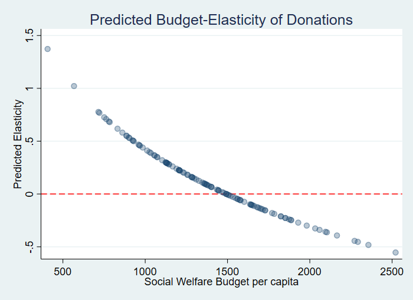

社会福祉予算と弾力性の散布図

```stata
* model 6: + squared logged government budge
eststo: xtreg log_total_g log_PPP_pubbdg sqlog_PPP_pubpdg log_price log_pinc_all ///
    age i.year##i.gender i.year##i.educ ///
    if year >= 2012, fe vce(cluster pid)

gen pred_e_pub = _b[log_PPP_pubbdg] + 2 * _b[sqlog_PPP_pubpdg] * log_PPP_pubbdg

keep pred_e_pub PPP_pubbdg year
keep if year >= 2012
duplicates drop

twoway  (scatter pred_e_pub PPP_pubbdg, mcolor(%30)), ///
        yline(0, lpattern(dash) lcolor(red)) ///
        xtitle("Social Welfare Budget per capita")  ///
        ytitle("Predicted Elasticity")  ///
        title("Predicted Budget-Elasticity of Donations")
graph export "_assets\baseline1.png", width(700) replace
```

## Government Trust and Crowding-in effect

政府支出の規模が小さいほど、寄付のクラウドインが生じるという結果を**政治家への信頼**で説明することを試みる。

**メカニズム**：政府支出の規模が小さいとき、個人は政府規模の増大に伴い、自身の寄付を増やそうと協力的な行動をとろうとする。しかし、政府支出が十分に大きいとき、政府規模が増大しても、個人は協力的な行動をとるインセンティブがない。よって、クラウドアウトが顕著に現れる。

このメカニズムを検討するために、政治家への信頼度`trust_politician`（`year >= 2015`で調査されている）を用いる。 政治家への信頼が薄いならば、政府の社会福祉政策に協力しようという気が起きないので、 標準的な理論通りの結果が得られる（政府支出の増大に伴い、金銭的寄付はクラウドアウトから漸近的にゼロクラウドアウトに向かう）。 しかしながら、政治家への信頼が強いならば、政府の社会福祉政策に協力しようという気が起きるので、 政府支出の増大に伴い、金銭的寄付はクラウドインから漸近的にゼロクラウドインに向かう。

推計式は

$$\log D_{ijt} = \beta_0 + \beta_1 \log G_{jt} * \mathrm{Trust}_{it} + \beta_2 (\log G_{jt})^2 * \mathrm{Trust}_{it} + \gamma_1 \log I_{ijt} + \gamma_2 \log P_{ijt} + \delta X_{ijt} + \mu_i + \lambda_t + \epsilon_{ijt}.$$

```stata
/*******************************************************************************

Government Trust and Crowd-in
Since trust for politicians can be observed if year >= 2015
We omit price of charitable giving

*******************************************************************************/

* intensive + extensive margin (public services)

eststo: xtreg log_total_g c.log_PPP_pubbdg##i.trust_politician c.sqlog_PPP_pubpdg##i.trust_politician ///
    log_pinc_all age i.year##i.gender i.year##i.educ ///
    if year >= 2015, fe vce(cluster pid)

esttab using "_assets\trust_elast.html", ///
    replace se ///
    keep(log_PPP_pubbdg sqlog_PPP_pubpdg ///
    2.trust_politician#c.log_PPP_pubbdg ///
    3.trust_politician#c.log_PPP_pubbdg ///
    4.trust_politician#c.log_PPP_pubbdg ///
    5.trust_politician#c.log_PPP_pubbdg ///
    2.trust_politician#c.sqlog_PPP_pubpdg ///
    3.trust_politician#c.sqlog_PPP_pubpdg ///
    4.trust_politician#c.sqlog_PPP_pubpdg ///
    5.trust_politician#c.sqlog_PPP_pubpdg)  ///
    title("Political Trust and Crowd-in") ///
    label star(* 0.1 ** 0.05 *** 0.01)
eststo clear
```

Political Trust and Crowd-in

|  | (1) |
| --- | --- |
|  | log_total_g |
| log_PPP_pubbdg | -9.696* |
|  | (5.533) |
| [世帯員]政治家への信頼度=2 # log_PPP_pubbdg | 12.80** |
|  | (6.389) |
| [世帯員]政治家への信頼度=3 # log_PPP_pubbdg | 12.78* |
|  | (7.350) |
| [世帯員]政治家への信頼度=4 # log_PPP_pubbdg | 2.420 |
|  | (10.69) |
| [世帯員]政治家への信頼度=5 # log_PPP_pubbdg | 12.96 |
|  | (19.57) |
| sqlog_PPP_pubpdg | 0.644* |
|  | (0.375) |
| [世帯員]政治家への信頼度=2 # sqlog_PPP_pubpdg | -0.859** |
|  | (0.433) |
| [世帯員]政治家への信頼度=3 # sqlog_PPP_pubpdg | -0.851* |
|  | (0.499) |
| [世帯員]政治家への信頼度=4 # sqlog_PPP_pubpdg | -0.148 |
|  | (0.727) |
| [世帯員]政治家への信頼度=5 # sqlog_PPP_pubpdg | -0.820 |
|  | (1.336) |
| Observations | 29807 |
| Standard errors in parentheses * *p* < 0.1, ** *p* < 0.05, *** *p* < 0.01 |  |

交差項が統計的に10%水準以下で有意である`trust_politician = 1, 2, 3`についての弾力性の予測性を以下にプロットした。

- 政治家への信頼が全くないグループ（`Lowest trust`）について、政府支出の増大に伴い、クラウドアウトからクラウドインに向かう
- 政治家への信頼が若干にあるグループ（`Lower trust`）とニュートラルなグループ（`Nuetral`）について、政府支出の増大に伴い、クラウドインからクラウドアウトに向かう

おそらく、**政治家への信頼に基づく政府に対する協力度が強いほど、標準的な理論から外れる行動を取る**

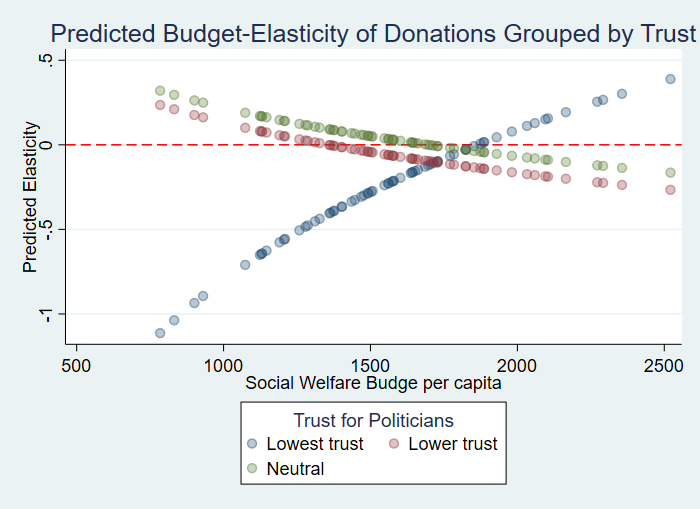

政治家への信頼と寄付の弾力性

```stata
eststo: xtreg log_total_g c.log_PPP_pubbdg##i.trust_politician c.sqlog_PPP_pubpdg##i.trust_politician ///
    log_pinc_all age i.year##i.gender i.year##i.educ ///
    if year >= 2015, fe vce(cluster pid)

gen pred_e_pub_sep = .
replace pred_e_pub_sep = _b[log_PPP_pubbdg] + 2 * _b[sqlog_PPP_pubpdg] * log_PPP_pubbdg if trust_politician == 1
replace pred_e_pub_sep = (_b[log_PPP_pubbdg] + _b[2.trust_politician#c.log_PPP_pubbdg]) + ///
    2 * (_b[sqlog_PPP_pubpdg] + _b[2.trust_politician#c.sqlog_PPP_pubpdg]) * log_PPP_pubbdg if trust_politician == 2
replace pred_e_pub_sep = (_b[log_PPP_pubbdg] + _b[3.trust_politician#c.log_PPP_pubbdg]) + ///
    2 * (_b[sqlog_PPP_pubpdg] + _b[3.trust_politician#c.sqlog_PPP_pubpdg]) * log_PPP_pubbdg if trust_politician == 3

keep pred_e_pub pred_e_pub_sep trust_politician PPP_pubbdg year
keep if year >= 2012
duplicates drop

* Predicted elasiticity of donations grouped by political trust
twoway (scatter pred_e_pub_sep PPP_pubbdg if year >= 2015 & trust_politician == 1, mcolor(%30))   ///
       (scatter pred_e_pub_sep PPP_pubbdg if year >= 2015 & trust_politician == 2, mcolor(%30))  ///
       (scatter pred_e_pub_sep PPP_pubbdg if year >= 2015 & trust_politician == 3, mcolor(%30)),  ///
       yline(0, lpattern(dash) lcolor(red))  ///
       xtitle("Social Welfare Budge per capita") ///
       ytitle("Predicted Elasticity")  ///
       legend(lab(1 "Lowest trust") lab(2 "Lower trust") lab(3 "Neutral") ///
       title("Trust for Politicians", size(medium)))  ///
       title("Predicted Budget-Elasticity of Donations Grouped by Trust")
graph export "_assets\trust_elast.png", width(700) replace
```

## Interaction between Giving Prices and Government Expenditure

最後に、政府の寄付税制政策に基づく寄付価格と政府支出の交互作用を推計する。 推計式は、

$$\log D_{ijt} = \beta_0 + \beta_1 \log G_{jt}*\log P_{ijt} + \beta_2 (\log G_{jt})^2*\log P_{ijt} + \gamma_1 \log I_{ijt} + \gamma_2 \log P_{ijt} + \delta X_{ijt} + \mu_i + \lambda_t + \epsilon_{ijt}.$$

結果として、**寄付価格と政府支出の交互作用は統計的に有意な影響を持っていなかった**

```stata
/*******************************************************************************

Interactions b/w giving prices and government expenditure

*******************************************************************************/

* intensive + extensive margin (public services)

* model 1: baseline
eststo: xtreg log_total_g c.log_PPP_pubbdg##c.log_price log_pinc_all i.year ///
    if year >= 2012, fe vce(cluster pid)

* model 2: + age
eststo: xtreg log_total_g c.log_PPP_pubbdg##c.log_price log_pinc_all age i.year ///
    if year >= 2012, fe vce(cluster pid)

* model 3: + education-time dummies
eststo: xtreg log_total_g c.log_PPP_pubbdg##c.log_price log_pinc_all age i.year##i.educ ///
    if year >= 2012, fe vce(cluster pid)

* model 4: + gender-time dummies
eststo: xtreg log_total_g c.log_PPP_pubbdg##c.log_price log_pinc_all age i.year##i.gender i.year##i.educ ///
    if year >= 2012, fe vce(cluster pid)

* model 5: + living_area
eststo: xtreg log_total_g c.log_PPP_pubbdg##c.log_price log_pinc_all age i.living_area i.year##i.gender i.year##i.educ ///
    if year >= 2012, fe vce(cluster pid)

* model 6: + squared logged government budge
eststo: xtreg log_total_g c.log_PPP_pubbdg##c.log_price sqlog_PPP_pubpdg c.sqlog_PPP_pubpdg#c.log_price log_pinc_all ///
    age i.year##i.gender i.year##i.educ ///
    if year >= 2012, fe vce(cluster pid)

esttab using "_assets\price_expenditure.html", ///
    replace se ///
    keep(log_PPP_pubbdg sqlog_PPP_pubpdg log_price ///
    c.log_PPP_pubbdg#c.log_price c.sqlog_PPP_pubpdg#c.log_price log_pinc_all)  ///
    order(log_PPP_pubbdg sqlog_PPP_pubpdg log_price ///
    c.log_PPP_pubbdg#c.log_price c.sqlog_PPP_pubpdg#c.log_price log_pinc_all) ///
    title("Interactions between Giving Prices and Government Expenditure")
```

Interactions between Giving Prices and Government Expenditure

|  | (1) | (2) | (3) | (4) | (5) | (6) |
| --- | --- | --- | --- | --- | --- | --- |
|  | log_total_g | log_total_g | log_total_g | log_total_g | log_total_g | log_total_g |
| log_PPP_pubbdg | 0.184 | 0.184 | 0.133 | 0.109 | 0.814** | 10.17 |
|  | (0.124) | (0.124) | (0.129) | (0.129) | (0.283) | (5.591) |
| sqlog_PPP_pubpdg |  |  |  |  |  | -0.722 |
|  |  |  |  |  |  | (0.402) |
| log_price | -3.828 | -3.827 | -2.736 | -1.456 | 0.816 | -23.87 |
|  | (5.171) | (5.171) | (5.355) | (5.344) | (5.473) | (118.2) |
| c.log_PPP_pubbdg#c.log_price | 0.397 | 0.397 | 0.218 | 0.0567 | -0.276 | 8.370 |
|  | (0.748) | (0.748) | (0.778) | (0.776) | (0.795) | (34.00) |
| c.sqlog_PPP_pubpdg#c.log_price |  |  |  |  |  | -0.736 |
|  |  |  |  |  |  | (2.443) |
| log_pinc_all | 5.371*** | 5.371*** | 5.217*** | 5.241*** | 5.256*** | 5.230*** |
|  | (0.959) | (0.959) | (0.958) | (0.957) | (0.957) | (0.955) |
| *N* | 54213 | 54213 | 54211 | 54211 | 54211 | 54211 |
| Standard errors in parentheses * *p* < 0.05, ** *p* < 0.01, *** *p* < 0.001 |  |  |  |  |  |  |